# R Notebook

Slhouette coefficient

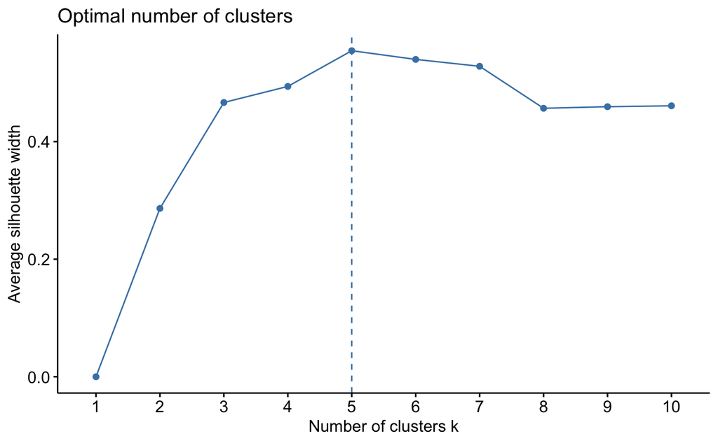

```r
fviz_nbclust(mall_tidy_scale, kmeans, method = "silhouette", nstart = 25)
```

k = 5 chosen above although k= 7 is also close to average width

Gap statistic

```
Clustering k = 1,2,..., K.max (= 10): .. done
Bootstrapping, b = 1,2,..., B (= 100)  [one "." per sample]:
.................................................. 50
.................................................. 100
```

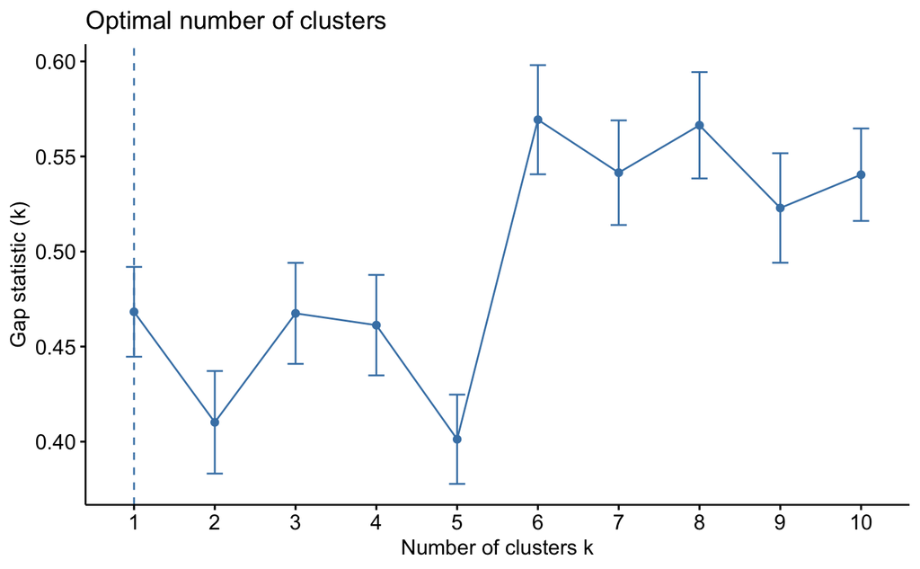

```r
fviz_nbclust(mall_tidy_scale, kmeans, method = "gap_stat")
```

Here k=1 showing. This is different to the above tests indicating that this data may not be well suited for k-means clustering.

However I would go with the sihouette method as it looks similar to the elbow method, at k = 5.

Visualise the clustering for your chosen value of k.

```r
clustered_mall_tidy <- kmeans(mall_tidy_scale, 5, nstart = 25)

clustered_mall_tidy
```

```
K-means clustering with 5 clusters of sizes 35, 22, 39, 23, 81

Cluster means:
  annual_income_k spending_score_1_100
1       1.0523622          -1.28122394
2      -1.3262173           1.12934389
3       0.9891010           1.23640011
4      -1.3042458          -1.13411939
5      -0.2004097          -0.02638995

Clustering vector:
  [1] 4 2 4 2 4 2 4 2 4 2 4 2 4 2 4 2 4 2 4 2 4 2 4 2 4 2 4 2 4 2 4 2 4 2 4 2 4 2 4 2 4 2 4 5 4 2 5 5 5 5 5 5
 [53] 5 5 5 5 5 5 5 5 5 5 5 5 5 5 5 5 5 5 5 5 5 5 5 5 5 5 5 5 5 5 5 5 5 5 5 5 5 5 5 5 5 5 5 5 5 5 5 5 5 5 5 5
[105] 5 5 5 5 5 5 5 5 5 5 5 5 5 5 5 5 5 5 5 3 1 3 5 3 1 3 1 3 5 3 1 3 1 3 1 3 1 3 5 3 1 3 1 3 1 3 1 3 1 3 1 3
[157] 1 3 1 3 1 3 1 3 1 3 1 3 1 3 1 3 1 3 1 3 1 3 1 3 1 3 1 3 1 3 1 3 1 3 1 3 1 3 1 3 1 3 1 3

Within cluster sum of squares by cluster:
[1] 18.304646  5.217630 19.655252  7.577407 14.485632
 (between_SS / total_SS =  83.6 %)

Available components:

[1] "cluster"      "centers"      "totss"        "withinss"     "tot.withinss" "betweenss"    "size"
[8] "iter"         "ifault"
```

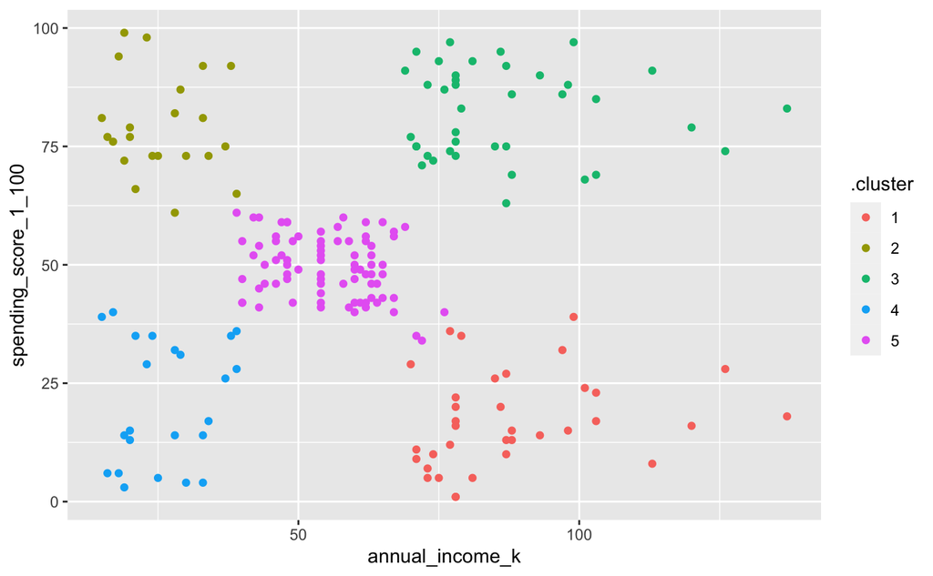

```r
clusters <- augment(clustered_mall_tidy, mall_tidy)

ggplot(clusters, aes(x = annual_income_k,
                     y = spending_score_1_100, colour = .cluster)) +
  geom_point()
```

Do you think the clustering seems a good fit for this data?

Yes, this creates 5 distinct clusters for the data, clusters 1 and 5 are very close however overall the groups are distinct.

Comment on the attributes on one or two of the clusters (maybe even give them a label if you like - like in section 4.1 of the ‘Segmentation & clustering intro’ lesson).

Cluster 5 appears a good one to use for the campaign since the data points are very close together. The next best option would appear to be cluster 2.